# toxicants in raptor

**Analysis for proportion exposed data**

*Modelling Approach*

- Here, we use a hierarchical beta-binomial (BB) model to assess the relationship between exposure to different toxicants and body mass (*Note: we might be interested in adding other covariates*). We use a BB model in order for us to inform the parameter for probability (i.e., proportion exposed) and account for varying sample size for each species and thus, overdispersion. The model has the form:

$$
$$\begin{align*}
Y_{ij} \sim Binom \ (n_{ij}, \ p_{ij}) \qquad \text{(Eqn.1)} \\
p_i \sim Beta \ (\gamma_1, \gamma_2)\qquad \text{(Eqn.2)} \\
\gamma_1 = \mu_1 * \phi ; \quad \gamma_2 = (1 - \mu_1) * \phi \qquad \text { (Eqn.3)} \\
\mu_1 = logit^{-1} (\alpha_{ij} + \Sigma (\beta_i*X_i)) \qquad \text { (Eqn. 4)}
\end{align*}$$
$$
In Eqn. 1, we are saying that our response variable (i.e., # exposed) follows a binomial distribution with the parameters *n* (sample size) and *p* (probability of exposure). The posterior of *p* is described by a beta distribution with shape hyperparameters, $\gamma_1$ and $\gamma_2$ (Eqn. 2). We reparameterize these hyperparameters to make it easier for us to see how our model is taking into account the variance in sample sizes by rewriting it in terms of a mean $\mu$ and overdispersion/variance, $\phi$ parameters (Eqn. 3). Then, we define the mean probability of exposure as the sum of the effects of linear terms and intercept that is allowed to vary per species, country, etc. (*still have to discuss how we want to approach this, but for now I’m thinking mass*).

*Results*

1. Visualizing the data

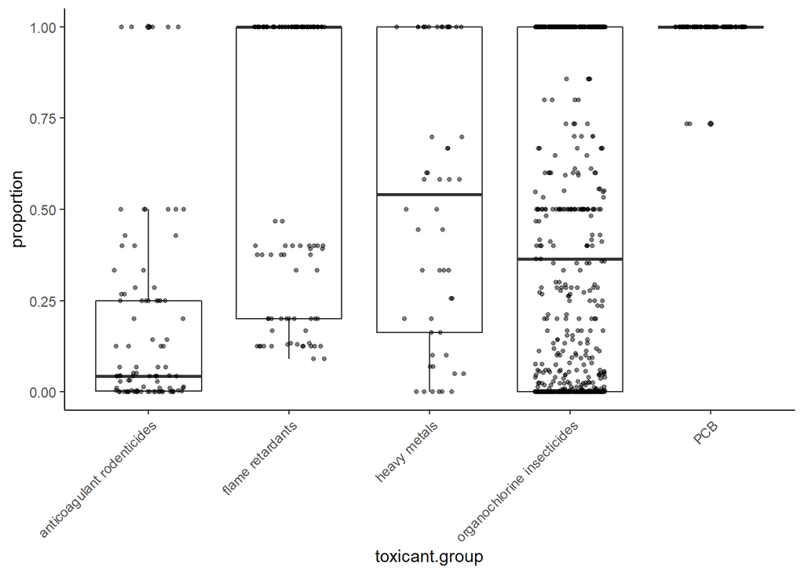

   P(exposure) of raptors to different toxicants

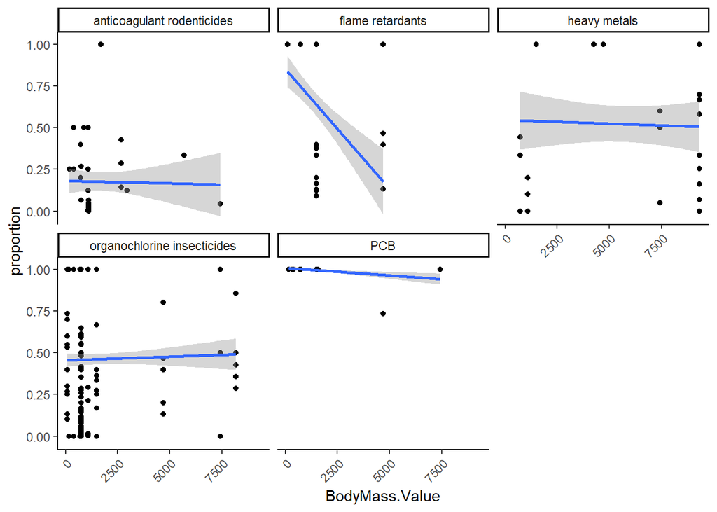

Relationship between P(exposure to toxicants) and body mass

2. BB model for all toxicants (no pooling for this) but intercept allowed to vary per species, country and study

```
## Inference for Stan model: 7c4d92a5ebaef5d7926477449d3575f5.
## 4 chains, each with iter=300; warmup=150; thin=1;
## post-warmup draws per chain=150, total post-warmup draws=600.
##
##               mean se_mean   sd  2.5%   25%   50%   75% 97.5% n_eff  Rhat
## alpha        -1.08    0.29 0.41 -1.77 -1.27 -0.96 -0.76 -0.65     2 13.50
## alpha_sp[1]   0.35    0.11 0.16  0.13  0.26  0.32  0.41  0.62     2 12.06
## alpha_sp[2]   0.94    0.42 0.59  0.18  0.62  0.83  1.19  1.90     2 23.05
## alpha_sp[3]   1.53    0.95 1.35  0.27  0.53  0.98  1.90  3.97     2 16.59
## alpha_sp[4]   1.42    1.22 1.74  0.03  0.33  0.62  1.62  4.70     2 20.22
## alpha_sp[5]   1.79    1.21 1.73  0.56  0.68  0.91  1.93  5.10     2 27.70
## alpha_sp[6]   3.67    4.00 5.68  0.17  0.20  0.49  3.53 14.57     2 19.39
## alpha_sp[7]   1.86    0.82 1.17  0.64  1.18  1.51  2.15  4.14     2 12.41
## alpha_sp[8]   1.37    0.75 1.07  0.37  0.71  0.95  1.57  3.38     2 18.91
## alpha_sp[9]   3.42    3.74 5.31  0.10  0.21  0.47  3.45 13.20     2 23.47
## alpha_sp[10]  1.09    0.47 0.67  0.36  0.54  0.91  1.45  2.23     2 16.69
## alpha_sp[11]  1.17    0.56 0.80  0.47  0.53  0.83  1.49  2.59     2 20.64
## alpha_sp[12]  0.67    0.34 0.48  0.05  0.32  0.62  0.96  1.46     2 15.52
## alpha_sp[13]  0.72    0.32 0.45  0.19  0.30  0.65  1.13  1.36     2 11.37
## alpha_sp[14]  0.91    0.25 0.36  0.53  0.57  0.82  1.15  1.51     2  7.47
## alpha_sp[15]  4.50    3.16 4.49  0.39  0.56  2.76  7.13 11.98     2 21.47
## alpha_sp[16]  1.21    0.43 0.61  0.54  0.61  1.08  1.82  2.01     2 12.61
## alpha_sp[17]  0.63    0.37 0.53  0.05  0.13  0.58  1.17  1.26     2 15.21
## alpha_sp[18]  0.81    0.57 0.81  0.03  0.16  0.49  1.21  2.20     2 21.26
## alpha_sp[19]  0.31    0.15 0.22  0.07  0.14  0.26  0.39  0.80     2  8.85
## alpha_sp[20]  0.86    0.58 0.82  0.18  0.22  0.44  1.17  2.30     2 23.96
## alpha_sp[21]  2.17    1.84 2.61  0.07  0.17  0.91  3.03  6.73     2 38.00
## alpha_sp[22]  0.73    0.43 0.61  0.11  0.12  0.59  1.31  1.51     2 25.39
## alpha_sp[23]  3.11    3.22 4.58  0.08  0.40  0.67  3.07 11.67     2 21.50
## alpha_sp[24]  4.93    3.34 4.77  1.02  1.13  2.75  6.61 13.92     2 19.11
## alpha_sp[25]  1.38    1.04 1.47  0.24  0.32  0.63  1.75  4.11     2 16.83
## alpha_sp[26]  0.71    0.26 0.38  0.36  0.40  0.55  0.93  1.42     2  9.31
## alpha_sp[27]  0.21    0.07 0.11  0.04  0.16  0.24  0.29  0.35     2  8.31
## mass_eff      0.00    0.00 0.00  0.00  0.00  0.00  0.00  0.00    13  1.14
##
## Samples were drawn using NUTS(diag_e) at Wed Jun 09 17:26:44 2021.
## For each parameter, n_eff is a crude measure of effective sample size,
## and Rhat is the potential scale reduction factor on split chains (at
## convergence, Rhat=1).
```

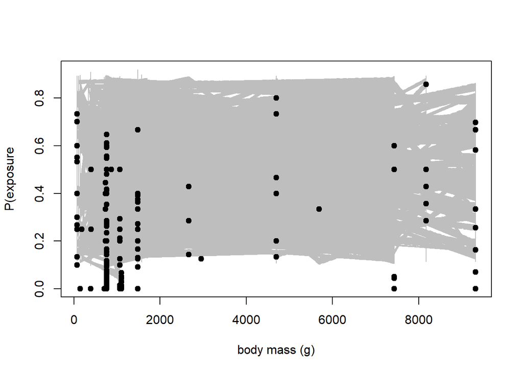

```r
dat_list=list( N=length(prop_data$Title),
               y=prop_data$exposed,
               n=prop_data$sample.size,
               mass=prop_data$BodyMass.Value,
               species=prop_data$spcode,
               country=prop_data$ctcode,
               study=prop_data$stcode,
               Nsp=length(unique(prop_data$spcode)),
               Nst=length(unique(prop_data$stcode)),
               Nct=length(unique(prop_data$ctcode)))

prop_mod=stan(model_code="

data{
  int<lower=0> N; // no.of obs
  int <lower=0> y[N];       // exposed
  int <lower=0>  n[N];       // sample size
  // real <lower=0, upper=1> proportion[N]; //proportion exposed
  int country [N];// country
  int species[N]; //ID of each species
  int study [N]; //ID of study
  int Nsp; //no.of species
  int Nst; //no.of studies
  int Nct; //no.of country
  vector [N] mass;
}

parameters {
  real alpha;// global intercept
  real mass_eff; // slope for mass
  real<lower=0> sigma_sp[Nsp];//errors for random effects
  real<lower=0> sigma_st[Nst];//errors for random effects
  real<lower=0> sigma_ct[Nct];//errors for random effects
  real <lower=0> phi;
  real <lower=0> sp_non;//non-centered error term for species
  real <lower=0> st_non;//non-centered error term for study
  real <lower=0> ct_non;//non-centered error term for country
  real <lower=0, upper=1> pred_exp[N] ;//exposure per observation
}

transformed parameters{
  vector <lower=0, upper=1> [N] prop_mu; //mean estimated exposure
  vector <lower=0> [N] A;
  vector <lower=0> [N] B;
  vector [Nsp] alpha_sp; //random intercept per species
  vector [Nst] alpha_st;// random intercept per study
  vector [Nct] alpha_ct;// random intercept per country

 //NCP of random terms:
  for (j in 1:Nsp) {

    alpha_sp[j]= sp_non*sigma_sp[j];
  }
  for (k in 1:Nst) {

    alpha_st[k]= st_non*sigma_st[k];
  }

  for (m in 1:Nct) {

    alpha_ct[m]= ct_non*sigma_ct[m];

  }

  //model:

    for (i in 1:N){

      prop_mu[i]= inv_logit(alpha+alpha_sp[Nsp]+alpha_st[Nst]+alpha_ct[Nct]+ mass_eff*mass[i]);
    }

  //reparameterize shape hyperparameters:
  A = prop_mu * phi;
  B = (1 - prop_mu)* phi;

}

model {
  //priors
  alpha~normal(0,1);
  mass_eff~normal(0,1);
  sp_non~ normal(0,1);
  st_non~ normal(0,1);
  ct_non~ normal(0,1);
  sigma_sp~ normal(0,1);
  sigma_st~ normal(0,1);
  sigma_ct~ normal(0,1);

  phi ~normal(0,1);// maybe set priors?

    //model likelihood:

    pred_exp ~ beta(A, B); // predicted exposure/proportion, beta dist.
  y~binomial(n, pred_exp); //no.of exposed drawn from binomial dist; based on sample size and reported survival estimate

}
",data=dat_list, chains=4, iter=300)
```

**Notes**  
* was this what you had in mind for approaching the proportion data? how should we go about the concentration data?  
* still have to do more tweaking for this model because convergence is terrible. do we want inform some of the parameters? how? which ones?  
* what other covariates do we want to add? how do we want to add the year effect?  
* should we build a separate model for each major toxicant group?